# Covid 19 Data Analysis

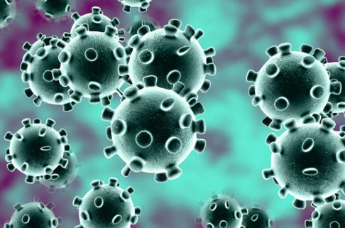

In this project , we will analyse Covid 19 data with respect to different regions.

Again, We will use Pandas library , to extract the dataset , analyse and to visualise it.

### Here are the questions, we will try to answer:-

1. show the number of confirmed, deaths and recovered cases in each region.
2. Remove all the records where Confirmed Cases is Less than 10.
3. In which region , maximum number of confirmed cases were recorded?
4. In which region minimum number of deaths were recorded?
5. How many Confirmed, Deaths and Recovered cases were reported from India till 29 April 2020?
6. Sort the entire data with respect to no of confirmed cases in ascending order.

[figure not shown]

```python
import pandas as pd
```

```python
data=pd.read_csv(r'C:\Users\MOUSAM KUMAR\Downloads\4. covid_19_data.csv')
```

```python
data.head(2)
```

|  | Date | State | Region | Confirmed | Deaths | Recovered |
| --- | --- | --- | --- | --- | --- | --- |
| 0 | 4/29/2020 | NaN | Afghanistan | 1939 | 60 | 252 |
| 1 | 4/29/2020 | NaN | Albania | 766 | 30 | 455 |

```python
data.shape
```

```
(321, 6)
```

```python
data.count()
# null value means missing values
```

```
Date         321
State        140
Region       321
Confirmed    321
Deaths       321
Recovered    321
dtype: int64
```

```python
data.State.isnull().sum()
```

```
181
```

```python
data.isnull().sum()
```

```
Date           0
State        181
Region         0
Confirmed      0
Deaths         0
Recovered      0
dtype: int64
```

```python
import seaborn as sns
import matplotlib.pyplot as plt
```

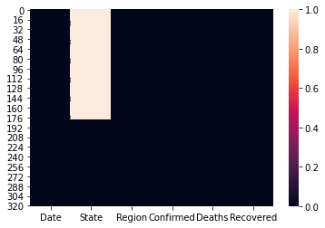

```python
sns.heatmap(data.isnull())
```

# 1.show the number of confirmed, deaths and recovered cases in each region.

```python
data.head(2)
```

|  | Date | State | Region | Confirmed | Deaths | Recovered |
| --- | --- | --- | --- | --- | --- | --- |
| 0 | 4/29/2020 | NaN | Afghanistan | 1939 | 60 | 252 |
| 1 | 4/29/2020 | NaN | Albania | 766 | 30 | 455 |

```python
data.groupby('Region').sum()
```

| Region | Confirmed | Deaths | Recovered |
| --- | --- | --- | --- |
| Afghanistan | 1939 | 60 | 252 |
| Albania | 766 | 30 | 455 |
| Algeria | 3848 | 444 | 1702 |
| Andorra | 743 | 42 | 423 |
| Angola | 27 | 2 | 7 |
| ... | ... | ... | ... |
| West Bank and Gaza | 344 | 2 | 71 |
| Western Sahara | 6 | 0 | 5 |
| Yemen | 6 | 0 | 1 |
| Zambia | 97 | 3 | 54 |
| Zimbabwe | 32 | 4 | 5 |

187 rows × 3 columns

```python
data.groupby('Region').sum().head(10)
```

| Region | Confirmed | Deaths | Recovered |
| --- | --- | --- | --- |
| Afghanistan | 1939 | 60 | 252 |
| Albania | 766 | 30 | 455 |
| Algeria | 3848 | 444 | 1702 |
| Andorra | 743 | 42 | 423 |
| Angola | 27 | 2 | 7 |
| Antigua and Barbuda | 24 | 3 | 11 |
| Argentina | 4285 | 214 | 1192 |
| Armenia | 1932 | 30 | 900 |
| Australia | 6752 | 91 | 5715 |
| Austria | 15402 | 580 | 12779 |

```python
data.groupby('Region')['Confirmed'].sum().sort_values(ascending=False)
```

```
Region
US                       1039909
Spain                     236899
Italy                     203591
France                    166543
UK                        166441
                          ...
Sao Tome and Principe          8
Papua New Guinea               8
Bhutan                         7
Western Sahara                 6
Yemen                          6
Name: Confirmed, Length: 187, dtype: int64
```

```python
data.groupby('Region')['Confirmed','Recovered'].sum()
```

| Region | Confirmed | Recovered |
| --- | --- | --- |
| Afghanistan | 1939 | 252 |
| Albania | 766 | 455 |
| Algeria | 3848 | 1702 |
| Andorra | 743 | 423 |
| Angola | 27 | 7 |
| ... | ... | ... |
| West Bank and Gaza | 344 | 71 |
| Western Sahara | 6 | 5 |
| Yemen | 6 | 1 |
| Zambia | 97 | 54 |
| Zimbabwe | 32 | 5 |

187 rows × 2 columns

# 2. Remove all the records where Confirmed Cases is Less than 10

```python
data.head(2)
```

|  | Date | State | Region | Confirmed | Deaths | Recovered |
| --- | --- | --- | --- | --- | --- | --- |
| 0 | 4/29/2020 | NaN | Afghanistan | 1939 | 60 | 252 |
| 1 | 4/29/2020 | NaN | Albania | 766 | 30 | 455 |

```python
data[~(data.Confirmed<10)]
#It remove the records temporarily
```

|  | Date | State | Region | Confirmed | Deaths | Recovered |
| --- | --- | --- | --- | --- | --- | --- |
| 0 | 4/29/2020 | NaN | Afghanistan | 1939 | 60 | 252 |
| 1 | 4/29/2020 | NaN | Albania | 766 | 30 | 455 |
| 2 | 4/29/2020 | NaN | Algeria | 3848 | 444 | 1702 |
| 3 | 4/29/2020 | NaN | Andorra | 743 | 42 | 423 |
| 4 | 4/29/2020 | NaN | Angola | 27 | 2 | 7 |
| ... | ... | ... | ... | ... | ... | ... |
| 316 | 4/29/2020 | Wyoming | US | 545 | 7 | 0 |
| 317 | 4/29/2020 | Xinjiang | Mainland China | 76 | 3 | 73 |
| 318 | 4/29/2020 | Yukon | Canada | 11 | 0 | 0 |
| 319 | 4/29/2020 | Yunnan | Mainland China | 185 | 2 | 181 |
| 320 | 4/29/2020 | Zhejiang | Mainland China | 1268 | 1 | 1263 |

304 rows × 6 columns

```python
data
```

|  | Date | State | Region | Confirmed | Deaths | Recovered |
| --- | --- | --- | --- | --- | --- | --- |
| 0 | 4/29/2020 | NaN | Afghanistan | 1939 | 60 | 252 |
| 1 | 4/29/2020 | NaN | Albania | 766 | 30 | 455 |
| 2 | 4/29/2020 | NaN | Algeria | 3848 | 444 | 1702 |
| 3 | 4/29/2020 | NaN | Andorra | 743 | 42 | 423 |
| 4 | 4/29/2020 | NaN | Angola | 27 | 2 | 7 |
| ... | ... | ... | ... | ... | ... | ... |
| 316 | 4/29/2020 | Wyoming | US | 545 | 7 | 0 |
| 317 | 4/29/2020 | Xinjiang | Mainland China | 76 | 3 | 73 |
| 318 | 4/29/2020 | Yukon | Canada | 11 | 0 | 0 |
| 319 | 4/29/2020 | Yunnan | Mainland China | 185 | 2 | 181 |
| 320 | 4/29/2020 | Zhejiang | Mainland China | 1268 | 1 | 1263 |

321 rows × 6 columns

```python
data=data[~(data.Confirmed<10)]
# It removes the confirmed cases less than 10 permanently
```

```python
data
```

|  | Date | State | Region | Confirmed | Deaths | Recovered |
| --- | --- | --- | --- | --- | --- | --- |
| 0 | 4/29/2020 | NaN | Afghanistan | 1939 | 60 | 252 |
| 1 | 4/29/2020 | NaN | Albania | 766 | 30 | 455 |
| 2 | 4/29/2020 | NaN | Algeria | 3848 | 444 | 1702 |
| 3 | 4/29/2020 | NaN | Andorra | 743 | 42 | 423 |
| 4 | 4/29/2020 | NaN | Angola | 27 | 2 | 7 |
| ... | ... | ... | ... | ... | ... | ... |
| 316 | 4/29/2020 | Wyoming | US | 545 | 7 | 0 |
| 317 | 4/29/2020 | Xinjiang | Mainland China | 76 | 3 | 73 |
| 318 | 4/29/2020 | Yukon | Canada | 11 | 0 | 0 |
| 319 | 4/29/2020 | Yunnan | Mainland China | 185 | 2 | 181 |
| 320 | 4/29/2020 | Zhejiang | Mainland China | 1268 | 1 | 1263 |

304 rows × 6 columns